# Fitting Swedish hip replacement model to subsampled data

ute

25.3.2021

Is the discrepancy between the coefficients of Eriks model, when fitted to Danish data, perhaps just due to the smaller sample size?

As a first experiment, we could look at the behaviour when fitted to subsamples of the Swedish data set. The following code collects results from 1000 subsamples and should not take long to run.

It would be fantastic if you could share the results with me :-)

```r
# change here for your own data paths, and adjust names where necessary

# ugly but useful
if (!endsWith(getwd(), "validation"))
  setwd("validation")

load("../cache/model_reduced_lean.RData")
load("../cache/df.RData")
SE_data <- df

N_SE <- nrow(SE_data)
N_DK <- 18854L

nsubsamp <- 1000

if (!file.exists("swedish_subsample_fits.Rdata")) {
  result <- replicate(nsubsamp,
      unlist(
          glm(model_reduced_lean$formula,
              binomial,
              data = SE_data[sample(N_SE, N_DK, replace = FALSE), ]
          )[c("coefficients", "deviance", "aic")]
      )
  )

  save(result, file="swedish_subsample_fits.Rdata")
}

load("swedish_subsample_fits.Rdata")

summary(t(result))
```

```
##  coefficients.(Intercept) coefficients.c_cns_diseaseTRUE
##  Min.   :-7.569           Min.   :0.005955
##  1st Qu.:-6.630           1st Qu.:0.576572
##  Median :-6.333           Median :0.683918
##  Mean   :-6.350           Mean   :0.679206
##  3rd Qu.:-6.086           3rd Qu.:0.797114
##  Max.   :-5.067           Max.   :1.199619
##  coefficients.c_fluid_electrolyte_disordersTRUE
##  Min.   :-13.1355
##  1st Qu.:  0.1524
##  Median :  0.4289
##  Mean   :  0.3566
##  3rd Qu.:  0.6756
##  Max.   :  1.5881
##  coefficients.c_liver_diseaseTRUE coefficients.P_ASAII coefficients.P_ASAIII
##  Min.   :-13.0417                 Min.   :-0.18975     Min.   :-0.04817
##  1st Qu.:  0.4705                 1st Qu.: 0.08276     1st Qu.: 0.33167
##  Median :  0.7434                 Median : 0.18630     Median : 0.44417
##  Mean   :  0.6959                 Mean   : 0.18762     Mean   : 0.44578
##  3rd Qu.:  0.9937                 3rd Qu.: 0.28259     3rd Qu.: 0.55571
##  Max.   :  1.6986                 Max.   : 0.64303     Max.   : 0.96229
##  coefficients.P_BMIoverweight coefficients.P_BMIclass I obesity
##  Min.   :-0.007365            Min.   :0.4277
##  1st Qu.: 0.312044            1st Qu.:0.7175
##  Median : 0.382041            Median :0.8087
##  Mean   : 0.388439            Mean   :0.8095
##  3rd Qu.: 0.468467            3rd Qu.:0.8987
##  Max.   : 0.741668            Max.   :1.2417
##  coefficients.P_BMIclass II-III obesity
##  Min.   :0.8943
##  1st Qu.:1.3015
##  Median :1.4024
##  Mean   :1.4022
##  3rd Qu.:1.5121
##  Max.   :1.9461
##  coefficients.P_DiaGrpSecondary osteoarthritis
##  Min.   :0.2437
##  1st Qu.:0.6398
##  Median :0.7387
##  Mean   :0.7323
```

[output cut: 22 more lines]

```
##  Max.   : 1.8510                                 Max.   :0.64432
##  coefficients.c_arrhythmiaTRUE coefficients.c_lung_airways_diseaseTRUE
##  Min.   :-0.2080               Min.   :-0.2141
##  1st Qu.: 0.1726               1st Qu.: 0.1548
##  Median : 0.2605               Median : 0.2716
##  Mean   : 0.2602               Mean   : 0.2633
##  3rd Qu.: 0.3546               3rd Qu.: 0.3703
##  Max.   : 0.6808               Max.   : 0.7710
##  coefficients.P_Age    deviance         aic
##  Min.   :0.008903   Min.   :3660   Min.   :3694
##  1st Qu.:0.019519   1st Qu.:4045   1st Qu.:4079
##  Median :0.023245   Median :4139   Median :4173
##  Mean   :0.023256   Mean   :4136   Mean   :4170
##  3rd Qu.:0.026939   3rd Qu.:4225   3rd Qu.:4259
##  Max.   :0.039145   Max.   :4540   Max.   :4574
```

# Compare model coefficients

```r
suppressPackageStartupMessages(library(tidyverse))

load("model_dk_superlean.RData")

cfs <-
  left_join(
    enframe(coef(model_reduced_lean)),
    enframe(coef(model_dk_superlean)),
    suffix = c(".se", ".dk"),
    by = "name"
  ) %>%
  rename(coef = name) %>%
  filter(!grepl("Intercept", coef)) %>%
  pivot_longer(starts_with("value"), names_to = "orig", names_prefix = "value.")
```

# Plot

Help function to plot the coefficients

```r
plot_result <- function(result, title) {
  d <-
    result %>%
    as_tibble(rownames = "coef") %>%
    filter(
      startsWith(coef, "coef"),
      !grepl("Intercept", coef),
    ) %>%
    pivot_longer(-coef) %>%
    filter(value > -5) %>%
    mutate(
      coef = gsub("coefficients\\.", "", coef),
      coef = reorder(coef, value, mean)
    )

  ci <-
    d %>%
    group_by(coef) %>%
    summarise(lo = quantile(value, 0.025), hi = quantile(value, 0.975)) %>%
    pivot_longer(c(lo, hi))

  p <-
    d %>%
    ggplot(aes(coef, value, color = coef)) +
    geom_point(position = position_dodge2(1), alpha = .33, show.legend = FALSE) +
    geom_boxplot(alpha = .5, size = 1, show.legend = FALSE) +
    geom_point(aes(shape = orig), data = cfs, size = 5, alpha = 1, color = "red") +
    geom_point(data = ci, size = 5, alpha = 1, color = "black") +
    geom_hline(aes(yintercept = 0), linetype = "dotted", color = "orange", size = 3) +
    coord_flip() +
    theme_minimal() +
    theme(legend.position = c(0, 1), legend.justification = c(0, 1))
    ggtitle(title)

    ggsave(paste0(title, ".png"), height = 20, width = 40, units = "cm")
    p
}
```

## Based on Swedish model

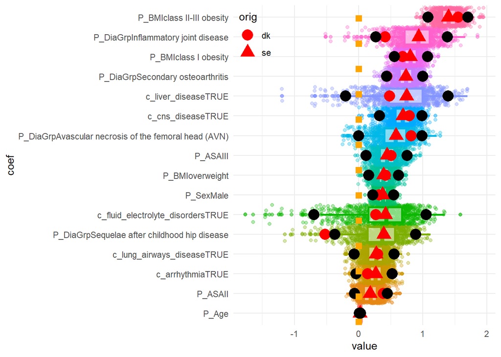

```r
plot_result(result, "Swedish model")
```

**Comment:** There were some additional outliers far outside of the plot Some of the coefficients are not different from 0 (no significant effect). This was expected for ASA II, which is only included since ASA III is. The difference between the Swedish and Danish estimates are relatively small. ## Based on Danish model

```r
if (!file.exists("dk_swedish_subsample_fits.Rdata")) {
  result_dk <-
    replicate(
      nsubsamp,
      unlist(
        glm(model_dk_superlean$formula,
            binomial,
            data = SE_data[sample(N_SE, N_DK, replace = FALSE), ]
        )[c("coefficients", "deviance", "aic")]
      )
    )

  save(result_dk, file="dk_swedish_subsample_fits.Rdata")
}
load("dk_swedish_subsample_fits.Rdata")

summary(t(result_dk))
```

```
##  coefficients.(Intercept) coefficients.c_cns_diseaseTRUE
##  Min.   :-7.412           Min.   :0.07474
##  1st Qu.:-6.560           1st Qu.:0.57380
##  Median :-6.308           Median :0.68790
##  Mean   :-6.326           Mean   :0.67911
##  3rd Qu.:-6.083           3rd Qu.:0.80140
##  Max.   :-5.210           Max.   :1.21691
##  coefficients.c_fluid_electrolyte_disordersTRUE
##  Min.   :-13.1918
##  1st Qu.:  0.1087
##  Median :  0.4074
##  Mean   :  0.3560
##  3rd Qu.:  0.6500
##  Max.   :  1.3754
##  coefficients.c_liver_diseaseTRUE coefficients.P_ASAII coefficients.P_ASAIII
##  Min.   :-13.0332                 Min.   :-0.22280     Min.   :-0.1611
##  1st Qu.:  0.4512                 1st Qu.: 0.09712     1st Qu.: 0.3388
##  Median :  0.7423                 Median : 0.17678     Median : 0.4464
##  Mean   :  0.6792                 Mean   : 0.18177     Mean   : 0.4477
##  3rd Qu.:  0.9957                 3rd Qu.: 0.26384     3rd Qu.: 0.5553
##  Max.   :  1.6057                 Max.   : 0.62822     Max.   : 0.9375
##  coefficients.P_BMIoverweight coefficients.P_BMIclass I obesity
##  Min.   :0.09554              Min.   :0.4091
##  1st Qu.:0.31781              1st Qu.:0.7204
##  Median :0.39467              Median :0.8016
##  Mean   :0.39488              Mean   :0.8079
##  3rd Qu.:0.46609              3rd Qu.:0.9029
##  Max.   :0.81631              Max.   :1.1992
##  coefficients.P_BMIclass II-III obesity
##  Min.   :0.7894
##  1st Qu.:1.2997
##  Median :1.4082
##  Mean   :1.4038
##  3rd Qu.:1.5147
##  Max.   :1.8668
##  coefficients.P_DiaGrpSecondary osteoarthritis
##  Min.   :0.2216
##  1st Qu.:0.6332
##  Median :0.7243
##  Mean   :0.7224
```

[output cut: 22 more lines]

```
##  Max.   : 1.6179                                 Max.   :0.64733
##  coefficients.c_arrhythmiaTRUE coefficients.c_lung_airways_diseaseTRUE
##  Min.   :-0.1539               Min.   :-0.4113
##  1st Qu.: 0.1725               1st Qu.: 0.1523
##  Median : 0.2609               Median : 0.2713
##  Mean   : 0.2611               Mean   : 0.2638
##  3rd Qu.: 0.3568               3rd Qu.: 0.3815
##  Max.   : 0.6632               Max.   : 0.7123
##  coefficients.P_Age    deviance         aic
##  Min.   :0.009753   Min.   :3612   Min.   :3646
##  1st Qu.:0.019625   1st Qu.:4049   1st Qu.:4083
##  Median :0.023093   Median :4138   Median :4172
##  Mean   :0.022959   Mean   :4136   Mean   :4170
##  3rd Qu.:0.026076   3rd Qu.:4224   3rd Qu.:4258
##  Max.   :0.039913   Max.   :4527   Max.   :4561
```

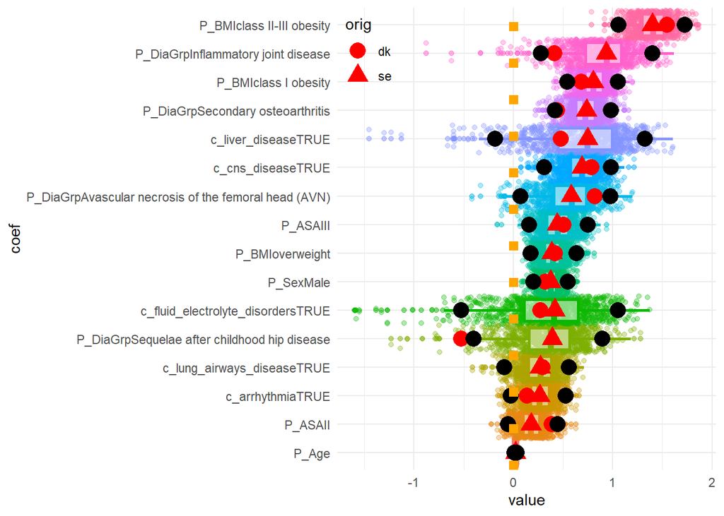

```r
plot_result(result_dk, "Danish model")
```

# AIC and deviance

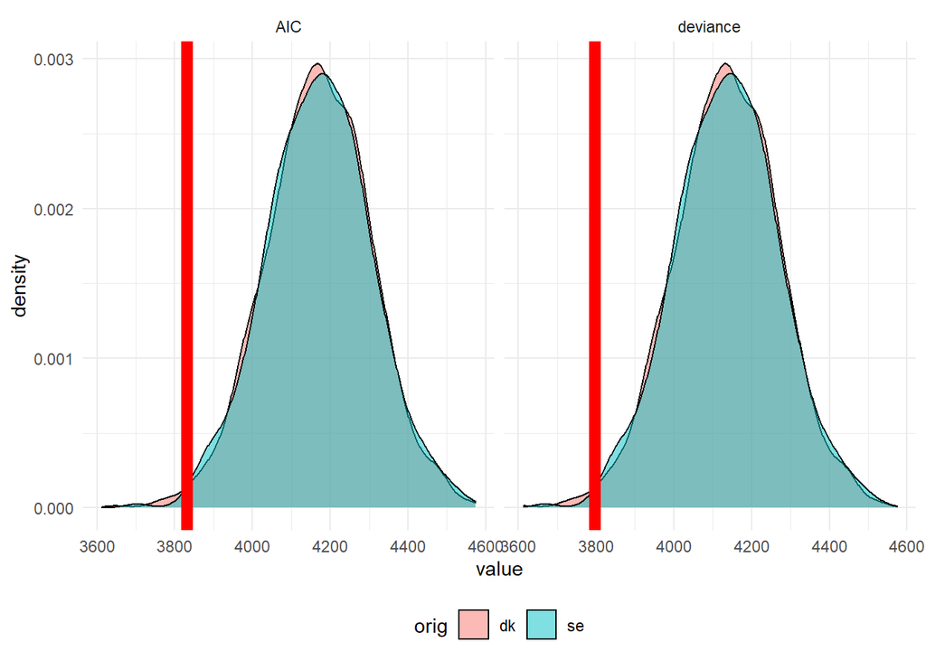

```r
aic_dev <-
  tibble(
    orig     = rep(c("se", "dk"), each = nsubsamp),
    AIC      = c(result["aic",], result_dk["aic",]),
    deviance = c(result["deviance",], result_dk["deviance",])
  ) %>%
  pivot_longer(c(AIC, deviance))

ggplot(aic_dev, aes(value, fill = orig)) +
  geom_density(alpha = .5) +
  geom_vline(
    aes(xintercept = x),
    tibble(name = "AIC", x = model_dk_superlean$aic),
    size = 3, color = "red") +
  geom_vline(
    aes(xintercept = x),
    tibble(name = "deviance", x = model_dk_superlean$deviance),
    size = 3, color = "red") +
  facet_wrap(~ name) +
  theme_minimal() +
  theme(legend.position = "bottom")
```

AIC values from both models overlap. The red line indicates the AIC from the Danish data. Hence, the model works better with Danish data. Significantly so? How many of the estimated values are at least as extreme as the one observed (should thos be two-tailed?):

```r
mean(sort(result["aic",]) <= model_dk_superlean$aic)
```

```
## [1] 0.004
```

# Predictive power of the Danish model on the Swedish data

We can try to use the model coefficients from the Danish data applied to the whole Swedish data set and estimate predictive power the same way as was done reversely before (as suggested by Ute).

```r
set.seed(123)
```

Useful packages

```r
purrr::walk(
  c("pROC", "rms", "givitiR"),
  ~suppressPackageStartupMessages(library(., character.only = TRUE))
)
```

use DK model with Swedish data

```r
obspred <-
  tibble(
    obs  = df$outcome,
    pred = predict(model_dk_superlean, df, type = "response")
  )
```

## ROC curve

```r
ROC <- pROC::roc(obspred, "obs", "pred", direction = "<")
```

```r
plot(ROC)
```

[output not shown]

## AUC

```r
AUCci <-
  pROC::ci.auc(
    ROC,
    method          = "bootstrap",
    boot.n          = 100,     # Remove this argument and use the default!
    boot.stratified = FALSE
  )
AUCci
```

```
## 95% CI: 0.6557-0.6774 (100 non-stratified bootstrap replicates)
```

## Calibration

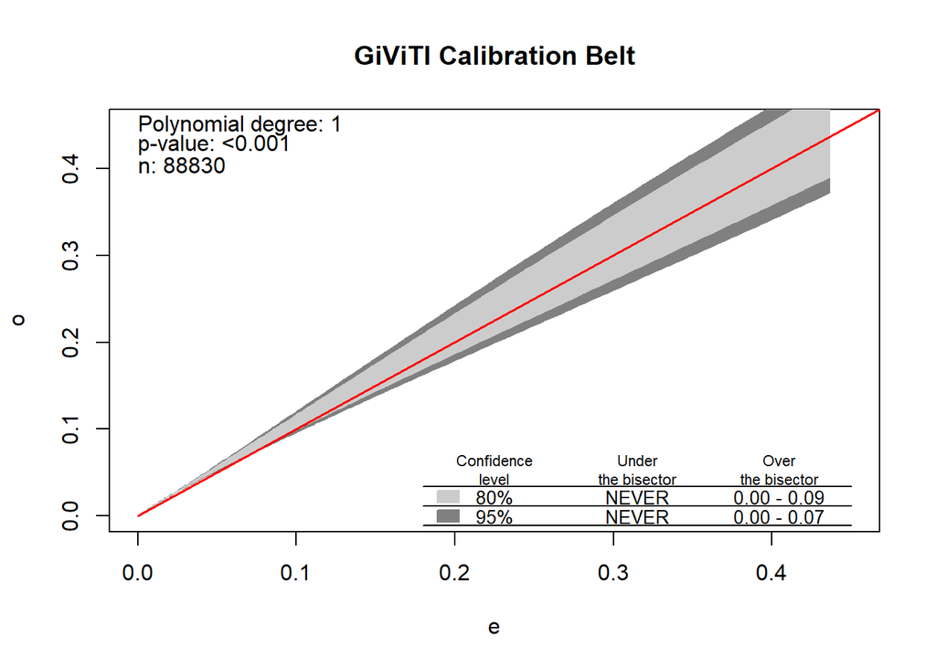

```
## $m
## [1] 1
##
## $p.value
## [1] 8.52937e-09
```

```r
calibration <-
  givitiR::givitiCalibrationBelt(
    as.numeric(obspred$obs),
    obspred$pred,
    devel = "external"
  )
plot(calibration, xlim = c(0, 0.45), ylim = c(0, 0.45))
```

## Recalibrate intercept

```r
Z <- predict(model_dk_superlean, df, type = "response")

# Refit the intercept using Z = a + Xb from above as offset
fit2 <- glm(df$outcome ~ 1, offset = Z)

# Same calibration and validation as above
obspred2     <- tibble(obs  = df$outcome, pred = predict(fit2, type = "response"))
ROC2         <- pROC::roc(obspred2, "obs", "pred", direction = "<")
```

```r
plot(ROC2)
```

[output not shown]

```r
AUCci2 <-
  pROC::ci.auc(
    ROC2,
    method = "bootstrap",
    boot.n = 100,     # Remove this argument and use the default!
    boot.stratified = FALSE
  )
AUCci2
```

```
## 95% CI: 0.6543-0.6804 (100 non-stratified bootstrap replicates)
```

```r
calibration2 <-
  givitiR::givitiCalibrationBelt(
    as.numeric(obspred2$obs),
    obspred2$pred,
    devel = "external"
  )
```

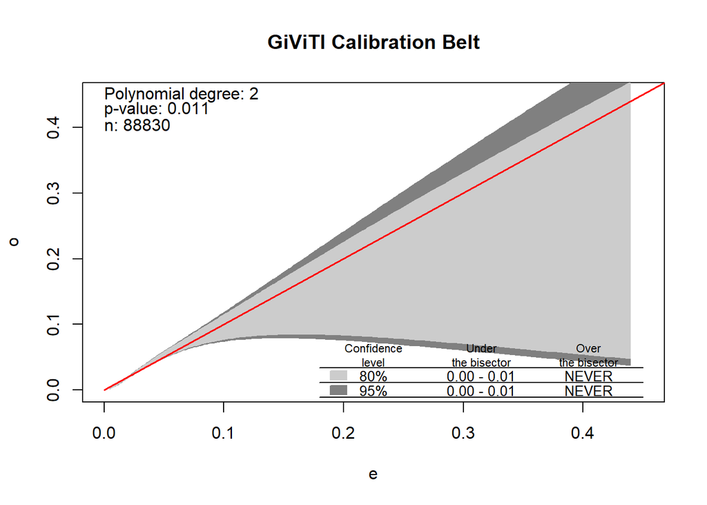

```
## $m
## [1] 2
##
## $p.value
## [1] 0.01078772
```

```r
plot(calibration2, xlim = c(0, 0.45), ylim = c(0, 0.45))
```

No good! ## Re-calibration of intercenpt and calibration slope

```r
fit3         <- glm(df$outcome ~ 1 + Z)
obspred3     <- tibble(obs  = df$outcome, pred = predict(fit3, type = "response"))
ROC3         <- pROC::roc(obspred3, "obs", "pred", direction = "<")
```

```r
plot(ROC3)
```

[output not shown]

```r
AUCci3 <-
  pROC::ci.auc(
    ROC3,
    method = "bootstrap",
    boot.n = 100,     # Remove this argument and use the default!
    boot.stratified = FALSE
  )
AUCci3
```

```
## 95% CI: 0.6516-0.6767 (100 non-stratified bootstrap replicates)
```

```r
calibration3 <-
  givitiR::givitiCalibrationBelt(
    as.numeric(obspred3$obs),
    obspred3$pred,
    devel = "external"
  )
```

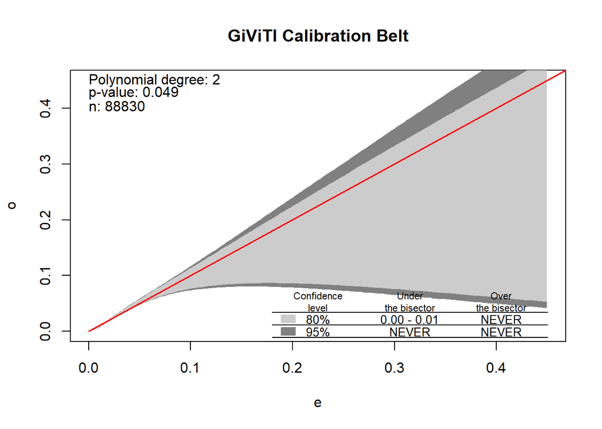

```
## $m
## [1] 2
##
## $p.value
## [1] 0.04934063
```

```r
plot(calibration3, xlim = c(0, 0.45), ylim = c(0, 0.45))
```